# Tests (loadtimes etc) for ABM

## App without auth (public)

Using `shinyloadtest` and `shinycannon` against “public” container.

Portainer graphs:

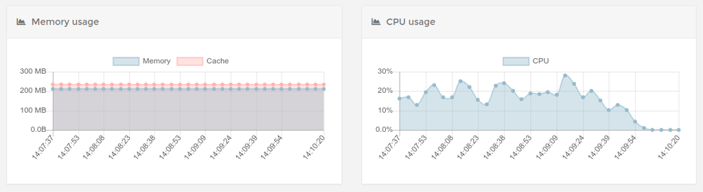

## App with SAML-auth

App deployed with shinyproxy using SAML auth integration.

Use `docker stats` to record memory consumed, or the `portainer` docker image.

```r
library(readr)
library(dplyr)
library(purrr)
library(stringr)

userz <-
  read_tsv("~/Downloads/top_users.csv") %>%
  mutate(account = str_match(name, "[(](.*?)[)]")[ ,2]) %>%
  rename(username = kthid) %>%
  mutate(password = "password12", groups = "employee") %>%
  select(username = account, password, groups)

urls_app <- tibble(
  user = userz %>% pull(username),
  pwd = userz %>% pull(password),
  url = "http://localhost:8000/app_direct/abm/"
)

write_csv(urls_app, "urls.txt", col_names = FALSE)
```

A bash script was used to launch the request in parallel (each of those 50 sessions did 10 requests with a concurrency of 2, simultaneously).

```r
# system("shinyload/loadtest.sh")
fn <- list.files(".", pattern = "abm-.*\\.txt$")

parse_result <- function(fn) {
  read_lines(fn) %>%
    str_subset(pattern = "(mean, across all concurrent requests)") %>%
    str_extract("(\\d+\\.\\d+)") %>%
    as.numeric()
}

# summary of response times across the whole test
tibble(fn, mean_ms = map_dbl(fn, parse_result)) %>%
summary()
```

```
##       fn               mean_ms
##  Length:50          Min.   : 20.18
##  Class :character   1st Qu.:335.16
##  Mode  :character   Median :369.68
##                     Mean   :400.52
##                     3rd Qu.:450.63
##                     Max.   :681.58
```

The host started and then garbage collected 50 containers:

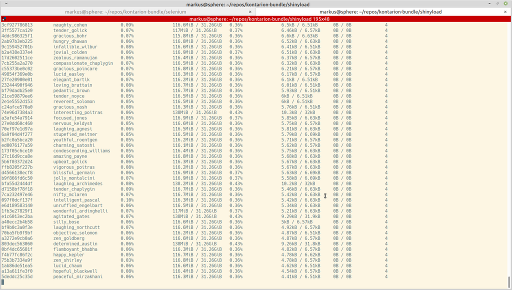

## API

For 50 concurrent users. Using “ab” tool to start 50 requests at once.

```r
urls_api <-
  urls_app %>%
  mutate(url = sprintf("http://localhost:8000/employee/%s/flexdashboard", user))

write_csv(urls_api, "urls.txt", col_names = FALSE)

# system("shinyload/loadtest.sh")

# summary of response times across the whole test
tibble(fn, mean_ms = map_dbl(fn, parse_result)) %>%
summary()
```

[output not shown]

Results when data was cached indicated fast respone times.

# Tools

The `cadvisor` tool can be used to monitor CPU/memory etc for containers running on the host:

```
sudo docker run \
  --volume=/:/rootfs:ro \
  --volume=/var/run:/var/run:ro \
  --volume=/sys:/sys:ro \
  --volume=/var/lib/docker/:/var/lib/docker:ro \
  --volume=/dev/disk/:/dev/disk:ro \
  --publish=7070:8080 \
  --detach=true \
  --name=cadvisor \
  gcr.io/google-containers/cadvisor:latest
```

The `portainer` docker image can be used for monitoring and getting stats for containers running on the host:

```
docker run -d -p 9000:9000 -p 6000:8000 --name portainer -v /var/run/docker.sock:/var/run/docker.sock -v portainer_data:/data portainer/portainer
```

# Running load tests locally

Steps for testing locally:

1. Build image: Use “kontarion” repo and the docker image “kthb/kontarion:latest”
2. Start services: Use “kontarion-bundle” repo, in shinyproxy dir issue
- docker-compose up -d api app shinyproxy
1. Verify local access at:
- http://localhost:8080 (for API)
- http://localhost:8090 (for public app)
- http://localhost:8000 (for app w SAML auth)

## Caches

Preparations, double-checking:

1. Launch app with one specific user (say jostran:password12) at
- http://localhost:8000/app_direct/abm
1. In that container, make sure caches have been created:
- `docker exec -it [shinproxy_container_name] R -e "library(bibliomatrix);prerender();prerender_cache_sync()"`
1. Double check that public app has environment variable ABM_IS_PUBLIC = “TRUE”